# S4 : Biodiversity data in R

Marine Ecological Modelling  
Global Climate Change

#### S4 : Biodiversity data in R

author: Jorge Assis  
contact: jmassis@ualg.pt  
code: github.com/jorgeassis  
tweets: twitter.com/jorgemfassis  
journal: [medium.com/theMarineDataScientist](https://medium.com/themarinedatascientist)

##### Biodiversity data [!]

Ecological niche models require georeferenced biodiversity occurrence data (e.g. species locations, which is the response or dependent variable). Such information are widely available in digital format (e.g., online repositories provide data on species distributions like GBIF).

```r
# always set a working directory
setwd(".")

# all packages needed and functions in external source file
source("sourceFunctions.R")
```

##### Plot occurrence data with R [!]

Function plot allows to produce a map of species occurrence records.

```r
# read records
records <- read.csv("Data/dataBases/gbif.csv", sep=";")
colnames(records)
```

```
##  [1] "gbifID"                           "datasetKey"
##  [3] "occurrenceID"                     "kingdom"
##  [5] "phylum"                           "class"
##  [7] "order"                            "family"
##  [9] "genus"                            "species"
## [11] "infraspecificEpithet"             "taxonRank"
## [13] "scientificName"                   "verbatimScientificName"
## [15] "verbatimScientificNameAuthorship" "countryCode"
## [17] "locality"                         "stateProvince"
## [19] "occurrenceStatus"                 "individualCount"
## [21] "publishingOrgKey"                 "decimalLatitude"
## [23] "decimalLongitude"                 "coordinateUncertaintyInMeters"
## [25] "coordinatePrecision"              "elevation"
## [27] "elevationAccuracy"                "depth"
## [29] "depthAccuracy"                    "eventDate"
## [31] "day"                              "month"
## [33] "year"                             "taxonKey"
## [35] "speciesKey"                       "basisOfRecord"
## [37] "institutionCode"                  "collectionCode"
## [39] "catalogNumber"                    "recordNumber"
## [41] "identifiedBy"                     "dateIdentified"
## [43] "license"                          "rightsHolder"
## [45] "recordedBy"                       "typeStatus"
## [47] "establishmentMeans"               "lastInterpreted"
## [49] "mediaType"                        "issue"
```

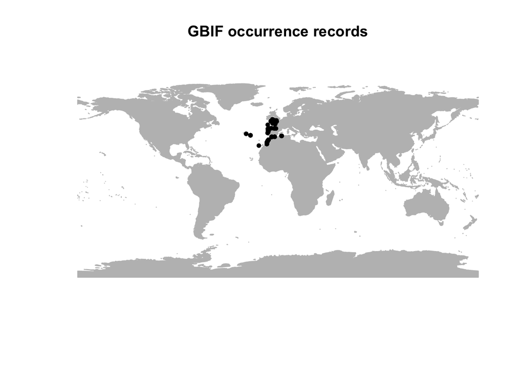

```r
# read a landmass polygon
world <- ne_countries(scale = 'medium')

plot(world,border="Gray",col="Gray",main="GBIF occurrence records")
points(records[,c("decimalLongitude","decimalLatitude")], pch=20)
```

###### Challenge 4.1

The main objetive of this challenge is to **collect** and **plot** biodiversity records from GBIF - http://gbif.org - and iNaturalist - https://inaturalist.org/.

[figure not shown]

[figure not shown]

```r
# packages, data and functions needed to accomplish the challenge
source("sourceFunctions.R")

data <- "Data/vectorShapefiles/globalLandmass/world.shp"

shapefile(path)
read.csv(path)
colnames(object)
View(object)
plot(object)
points(object)
```

##### Download data with R [!]

GBIF and OBIS contain worldwide occurrence records from observations as well as museum records.

```r
# download GBIF records for a species (genus species)
recordsGBIF <- getOccurrencesGBIF("Laminaria ochroleuca")
```

```
## 1392 records found
```

```
## 0-300-600-900-1200-1392 records downloaded
```

```r
nrow(recordsGBIF)
```

```
## [1] 1392
```

```r
colnames(recordsGBIF)
```

```
## [1] "Name"      "Locality"  "Lon"       "Lat"       "Depth"     "dateYear"
## [7] "dateMonth" "dateDay"
```

```r
head(recordsGBIF[,"dateYear"])
```

```
## [1] 2020 2020 2020 2020 2020 2020
```

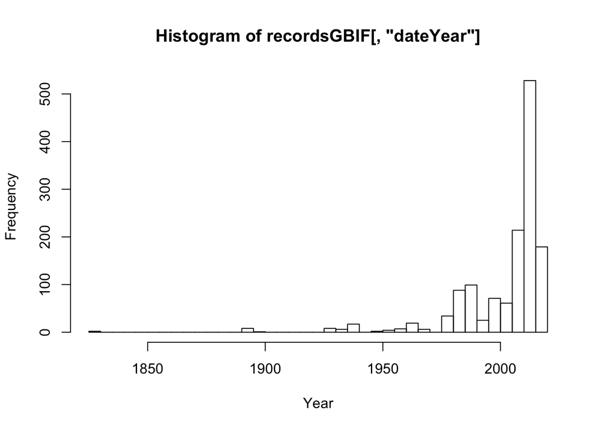

```r
hist(recordsGBIF[,"dateYear"],breaks=50,xlab="Year")
```

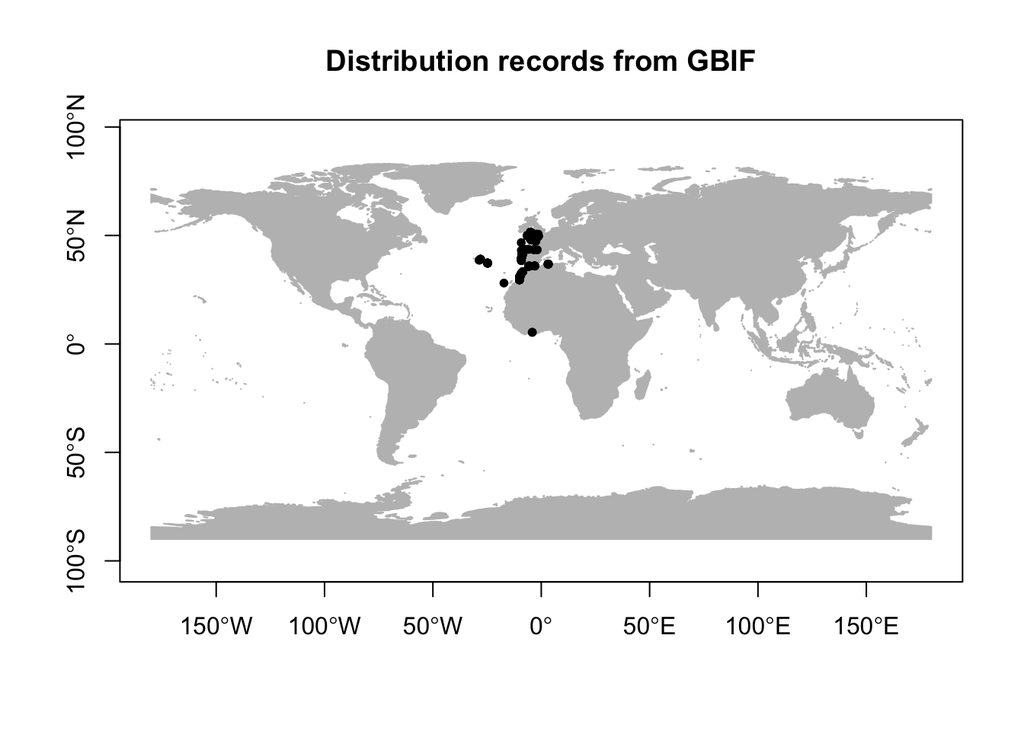

```r
# get landmass polygon from package
world <- ne_countries(scale = 'medium')

plot(world, col="Gray", border="Gray", axes=TRUE, main="Distribution records from GBIF" )
points(recordsGBIF[,c("Lon","Lat")], pch=20, col="Black")
```

```r
# download OBIS records for a species (genus species)
recordsOBIS <- getOccurrencesObis("Laminaria ochroleuca")
```

```
## Retrieved 242 records of approximately 242 (100%)
```

```r
nrow(recordsOBIS)
```

```
## [1] 242
```

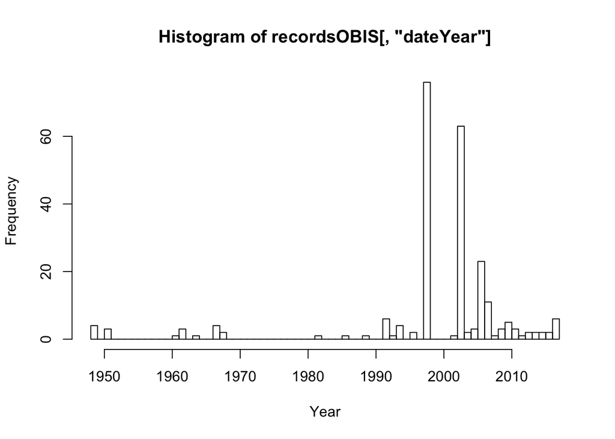

```r
hist(recordsOBIS[,"dateYear"],breaks=50,xlab="Year")
```

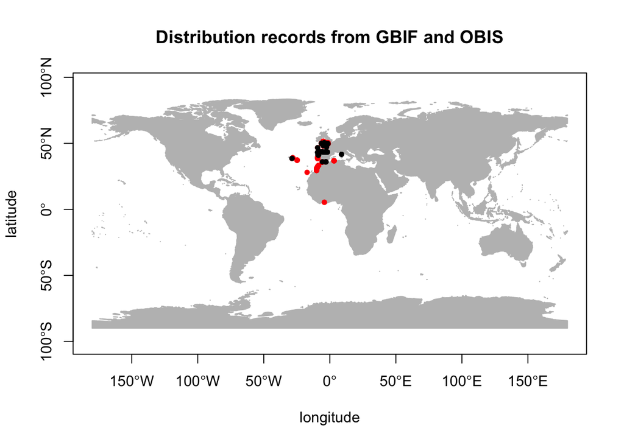

```r
plot(world, col="Gray", border="Gray", axes=TRUE, main="Distribution records from GBIF and OBIS" , ylab="latitude", xlab="longitude")
points(recordsGBIF[,c("Lon","Lat")], pch=20, col="Red")
points(recordsOBIS[,c("Lon","Lat")], pch=20, col="Black")
```

##### Merging different sources of biodiversity data [!]

When merging different data sources to obtain a unique dataset, column names must match!

```r
# download GBIF records for a species (genus species)
recordsGBIF <- getOccurrencesGBIF("Laminaria ochroleuca")
```

```
## 1392 records found
```

```
## 0-300-600-900-1200-1392 records downloaded
```

```r
colnames(recordsGBIF)
```

```
## [1] "Name"      "Locality"  "Lon"       "Lat"       "Depth"     "dateYear"
## [7] "dateMonth" "dateDay"
```

```r
recordsOBIS <- getOccurrencesObis("Laminaria ochroleuca")
```

```
## Retrieved 242 records of approximately 242 (100%)
```

```r
colnames(recordsGBIF)
```

```
## [1] "Name"      "Locality"  "Lon"       "Lat"       "Depth"     "dateYear"
## [7] "dateMonth" "dateDay"
```

```r
recordsInaturalist <- read.csv("Data/dataBases/inaturalist.csv",sep=",")
colnames(recordsInaturalist)
```

```
##  [1] "id"                               "observed_on_string"
##  [3] "observed_on"                      "time_observed_at"
##  [5] "time_zone"                        "out_of_range"
##  [7] "user_id"                          "user_login"
##  [9] "created_at"                       "updated_at"
## [11] "quality_grade"                    "license"
## [13] "url"                              "image_url"
## [15] "sound_url"                        "tag_list"
## [17] "description"                      "id_please"
## [19] "num_identification_agreements"    "num_identification_disagreements"
## [21] "captive_cultivated"               "oauth_application_id"
## [23] "place_guess"                      "latitude"
## [25] "longitude"                        "positional_accuracy"
## [27] "geoprivacy"                       "taxon_geoprivacy"
## [29] "coordinates_obscured"             "positioning_method"
## [31] "positioning_device"               "species_guess"
## [33] "scientific_name"                  "common_name"
## [35] "iconic_taxon_name"                "taxon_id"
```

```r
# Subset occurrences to get only coordinates
recordsGBIF <- recordsGBIF[,c("Lon","Lat")]
head(recordsGBIF)
```

```
##         Lon      Lat
## 1 -5.502159 50.12457
## 2 -9.123447 38.43132
## 3 -2.330840 48.68806
## 4 -9.205328 38.40867
## 5 -9.205328 38.40867
## 6 -8.877663 41.74413
```

```r
# Subset occurrences to get only coordinates
recordsOBIS <- recordsOBIS[,c("Lon","Lat")]
head(recordsOBIS)
```

```
##         Lon      Lat
## 1 -8.853889 41.69722
## 2 -8.870000 41.75000
## 3 -3.056550 48.83898
## 4 -3.917920 43.48055
## 5 -4.086270 43.43899
## 6 -4.136071 50.33825
```

```r
# Subset occurrences to get only coordinates
recordsInaturalist <- recordsInaturalist[,c("longitude","latitude")]
head(recordsInaturalist)
```

```
##   longitude latitude
## 1 -8.901982 42.19261
## 2 -5.607340 36.00538
## 3 -6.323150 49.88622
## 4 -6.264500 49.96988
## 5 -8.852559 41.69546
## 6 -3.982053 48.72867
```

Row binding (rbind) data.frames with different column names will retrieve an error.  
Columns must be renamed to allow merging distinct datasets.

```r
records <- rbind(recordsGBIF,recordsOBIS,recordsInaturalist)
```

```
## Error in match.names(clabs, names(xi)): names do not match previous names
```

```r
colnames(recordsInaturalist) <- c("Lon","Lat")
records <- rbind(recordsGBIF,recordsOBIS,recordsInaturalist)
nrow(records)
```

```
## [1] 1644
```

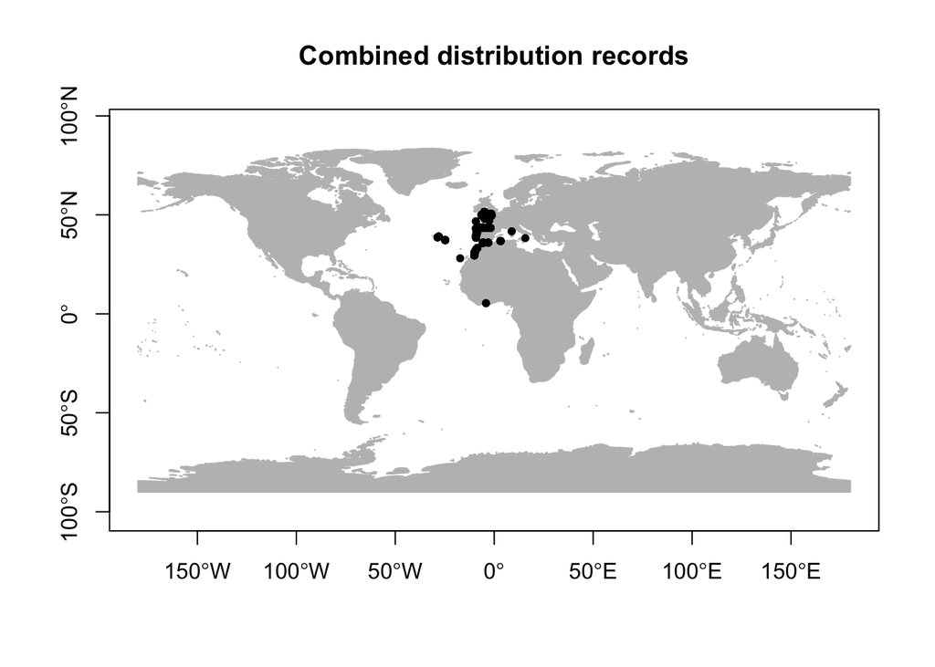

```r
plot(world, col="Gray", border="Gray", axes=TRUE, main="Combined distribution records")
points(records, pch=20, col="Black")
```

###### Challenge 4.2

The main objetive of this challenge is to **collect** and **merge** biodiversity data from different sources (inaturalist and GBIF) for a species of your interest.

```r
# packages, data and functions needed to accomplish the challenge
source("sourceFunctions.R")

data <- "Data/vectorShapefiles/globalLandmass/world.shp"

read.csv(path)
shapefile(path)
getOccurrencesGBIF("species")
colnames(object)
rbind(objet,object)
plot(object)
points(object)
```

##### Data cleaning in R [!]

Data ‘cleaning’ is particularly important for data sourced from data warehouses such as GBIF.

###### Remove NA coordinates

```r
# get data from GBIF
records <- getOccurrencesGBIF("Laminaria ochroleuca")
```

```
## 1392 records found
```

```
## 0-300-600-900-1200-1392 records downloaded
```

```r
# remove NA coordinates; Give the proper Longitude and Latitude column names
records <- removeNA(records,"Lon","Lat")
```

```
## Removing 204 NA records
```

```r
sum( is.na( records[,"Lon"] ) )
```

```
## [1] 0
```

###### Remove duplicate coordinates

```r
# remove duplicate coordinates; Give the proper Longitude and Latitude column names
records <- removeDuplicated(records,"Lon","Lat")
```

```
## Removing 597 NA records
```

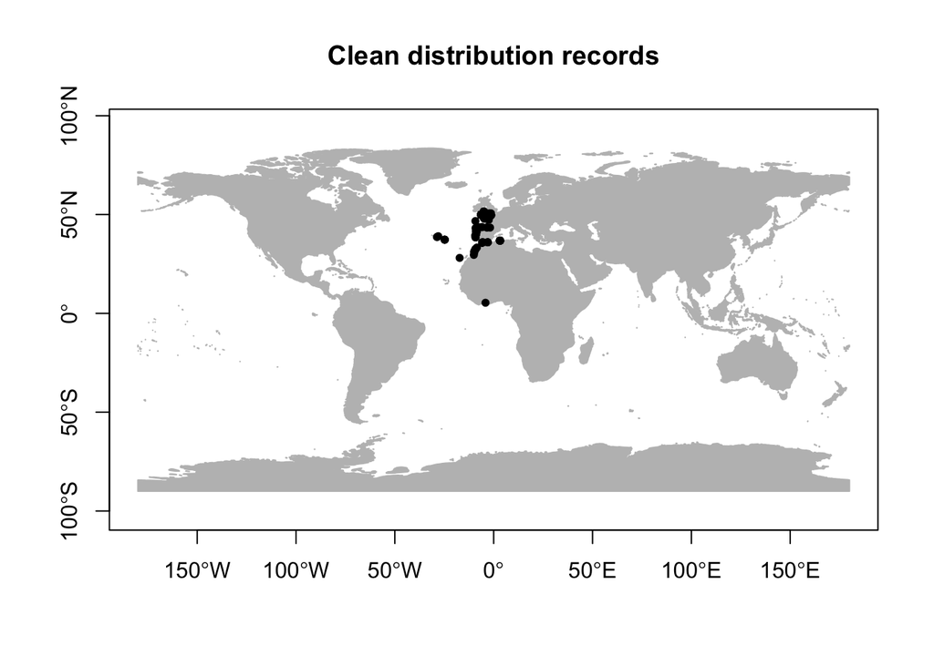

```r
plot(world, col="Gray", border="Gray", axes=TRUE, main="Clean distribution records")
points(records[,c("Lon","Lat")], pch=20, col="Black")
```

###### Remove records outside known distributions

```r
# consider a species that only occurs from Morocco to Ireland and in the Azores
# use defineRegion() to define the region where the species occur and then selectRecords()

records <- getOccurrencesGBIF("Laminaria ochroleuca")
```

```
## 1392 records found
```

```
## 0-300-600-900-1200-1392 records downloaded
```

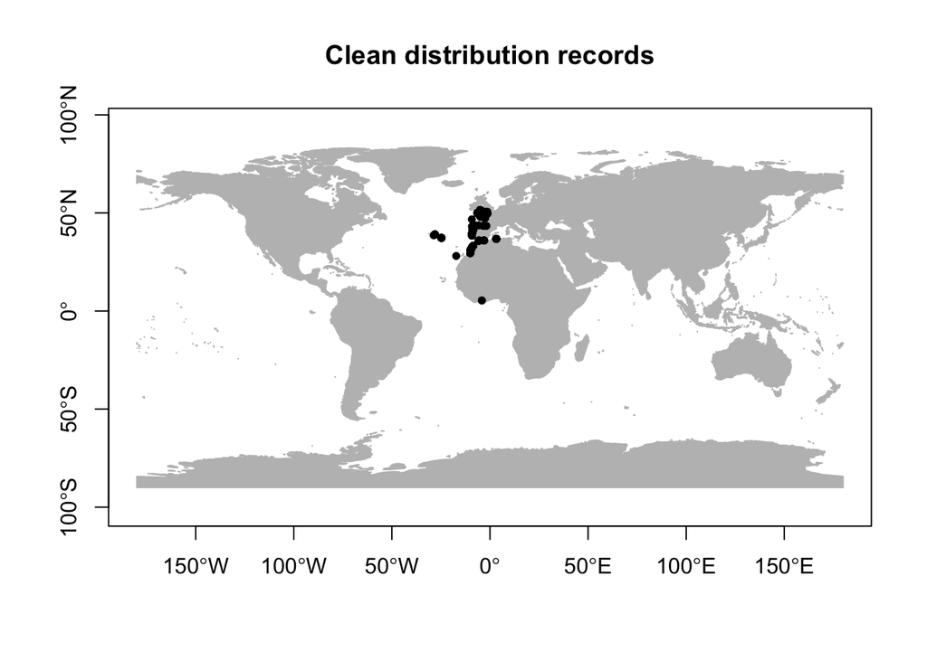

```r
# use function defineRegion() to choose the region where the species occur.
# draw a polygon of the region of interest, click finish and close the window.
# use function selectRecords() to select the records within the region of interest; Give the proper Longitude and Latitude column names

# defineRegion(records,"Lon","Lat")
# records <- selectRecords(records,"Lon","Lat")

plot(world, col="Gray", border="Gray", axes=TRUE, main="Clean distribution records")
points(records[,c("Lon","Lat")], pch=20, col="Black")
```

```r
# remove records outside known vertical distribution (e.g., species only occur down to 80m depths)
bathymetry <- raster("Data/rasterLayers/BathymetryDepthMean.tif")
depthUse <- extract(bathymetry,records[,c("Lon","Lat")])
head(depthUse)
```

```
## [1]  -21  -76  -13 -414 -414  -29
```

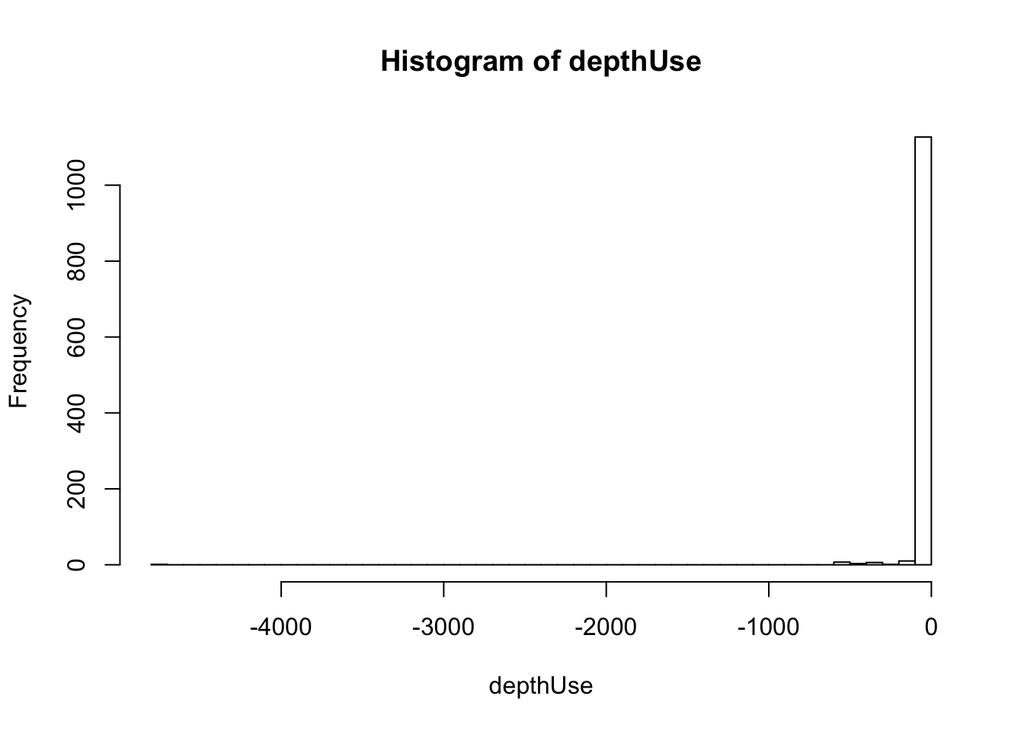

```r
hist(depthUse,breaks=50,na.rm=T)
```

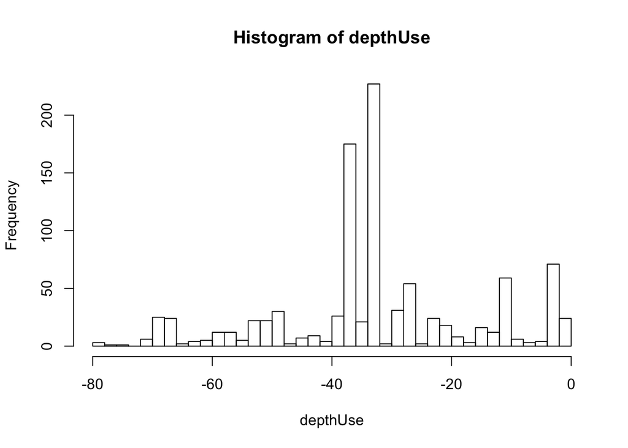

```r
records <- records[ depthUse > -80 ,]

depthUse <- extract(bathymetry,records[,c("Lon","Lat")])
hist(depthUse,breaks=50,na.rm=T)
```

###### Remove records on land

```r
# identify and remove records on land
records <- removeOverLand(records,"Lon","Lat")
```

[output not shown]

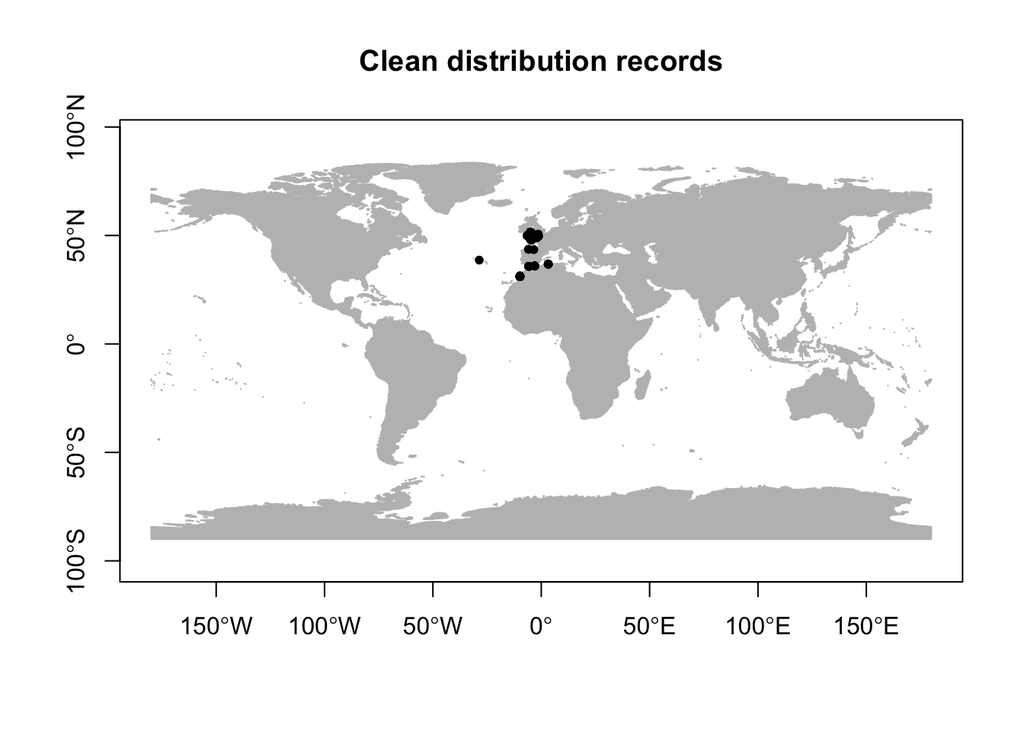

```r
plot(world, col="Gray", border="Gray", axes=TRUE, main="Clean distribution records")
points(records[,c("Lon","Lat")], pch=20, col="Black")
```

```r
nrow(records)
```

```
## [1] 508
```

###### Challenge 4.3

The main objetive of this challenge is to **collect** biodiversity data from GBIF and OBIS in R, **clean records** and produce a **plot**. For this challenge use the species Laminaria ochroleuca.

```r
# packages, data and functions needed to accomplish the challenge
source("sourceFunctions.R")

# Species: Laminaria ochroleuca
# Information: The species only occur from morocco to Brittany (NE Atlantic), in the Azores and the Western Mediterranean Sea at maximum depths of 80m

# Use Recipe #1
# 1. get records with getOccurrencesGBIF() and getOccurrencesObis()
# 2. remove NA coordinates
# 4. remove duplicate coordinates with duplicated()
# 5. identify  records outside the know distibution (also depth)
# 6. remove records on land
# 8. plot records with plot() and ggplot()
```

###### Challenge 4.4

The main objetive of this challenge is to **collect** biodiversity data from GBIF and OBIS in R and also from iNaturalist, **clean records**, produce a **plot** and **save** records for latter use. For this challenge use a species of your own interest.

```r
# packages, data and functions needed to accomplish the challenge
source("sourceFunctions.R")

# Species: ***
# Information: ***

# Use Recipe #1
# 1. get records with getOccurrencesGBIF() and getOccurrencesObis()
# 2. remove NA coordinates
# 4. remove duplicate coordinates with duplicated()
# 5. identify  records outside the know distibution (also depth)
# 6. remove records on land
# 8. plot records with plot() and ggplot()
# 9. Save records with write.table()
```

R Markdown tutorial developed by Jorge Assis under the International License [[CC BY 4.0]](https://creativecommons.org/licenses/by/4.0/). When using, copying or modifying, the attribution citation should be **Assis, J. (2020) Marine Ecological Modelling and Global Climate Change. theMarineDatasSientist**.